# Cort explorations

2024-02-20

## Some important correlations

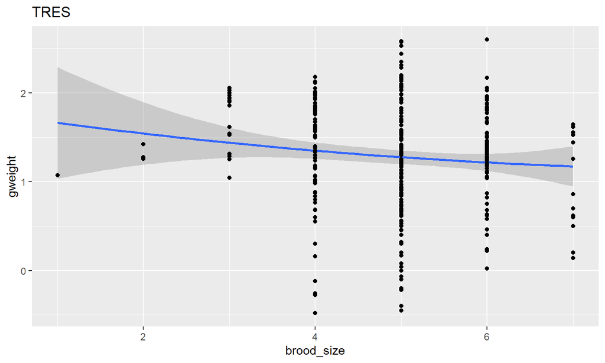

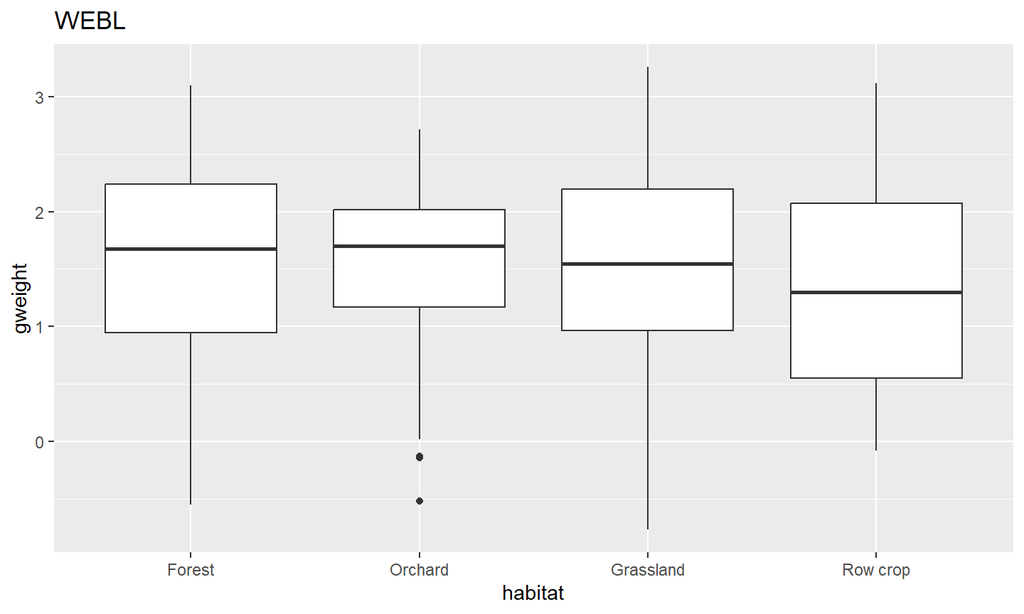

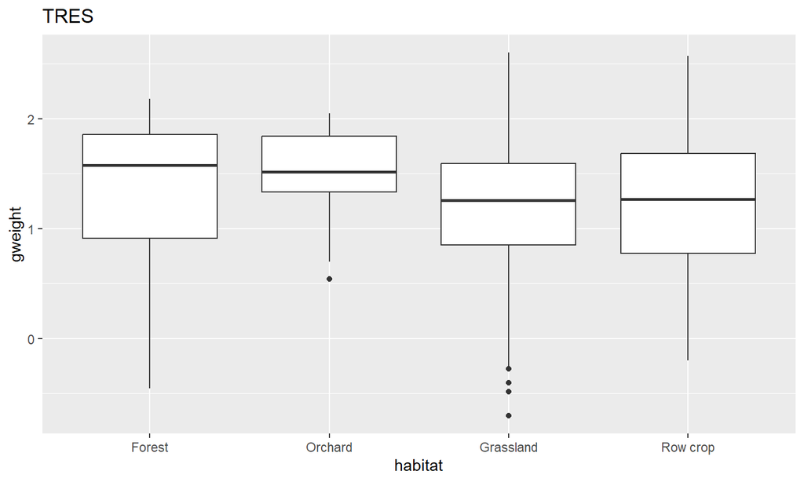

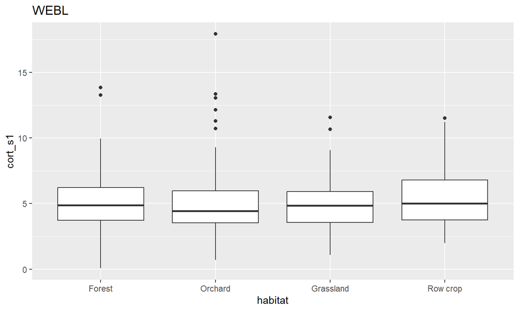

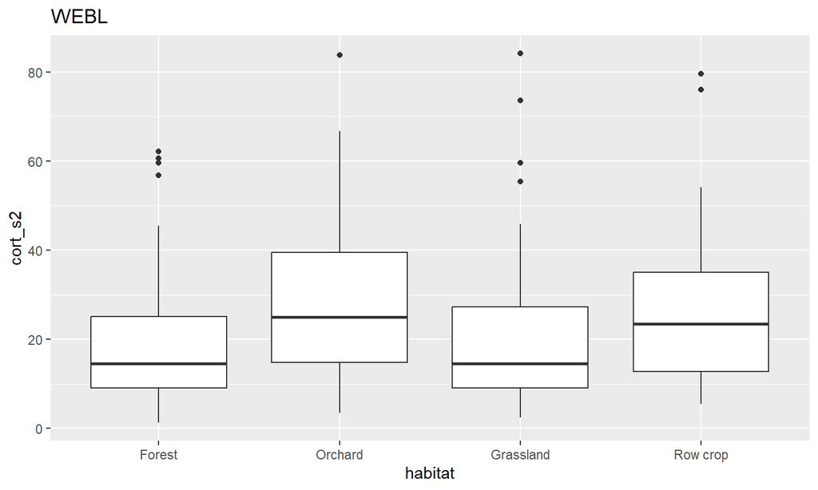

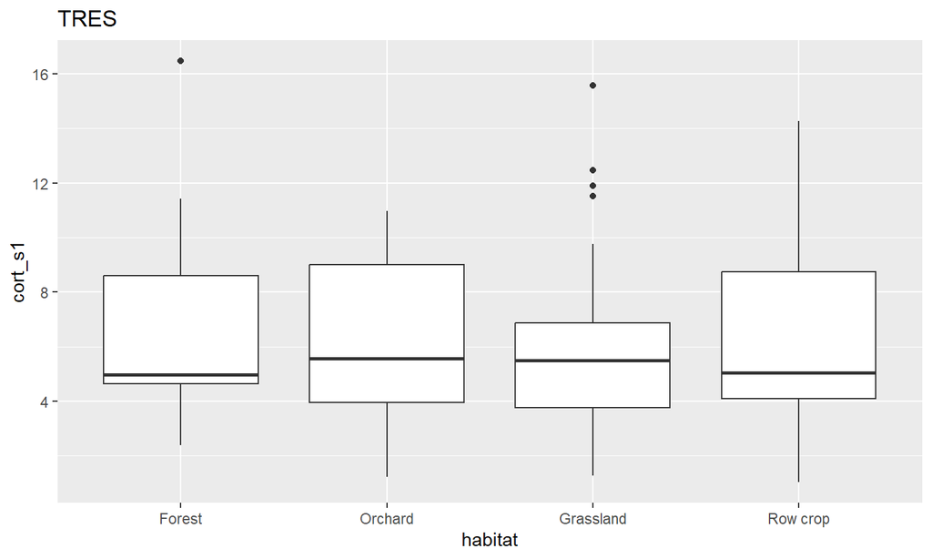

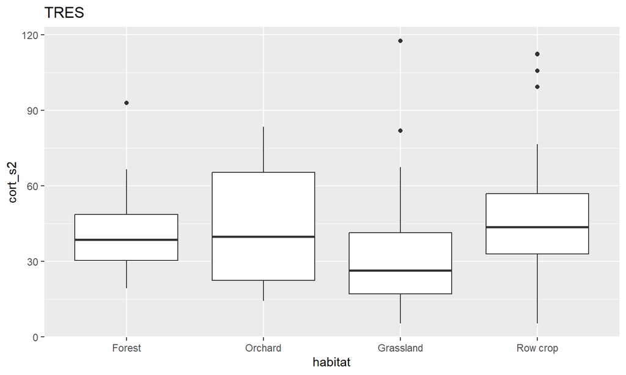

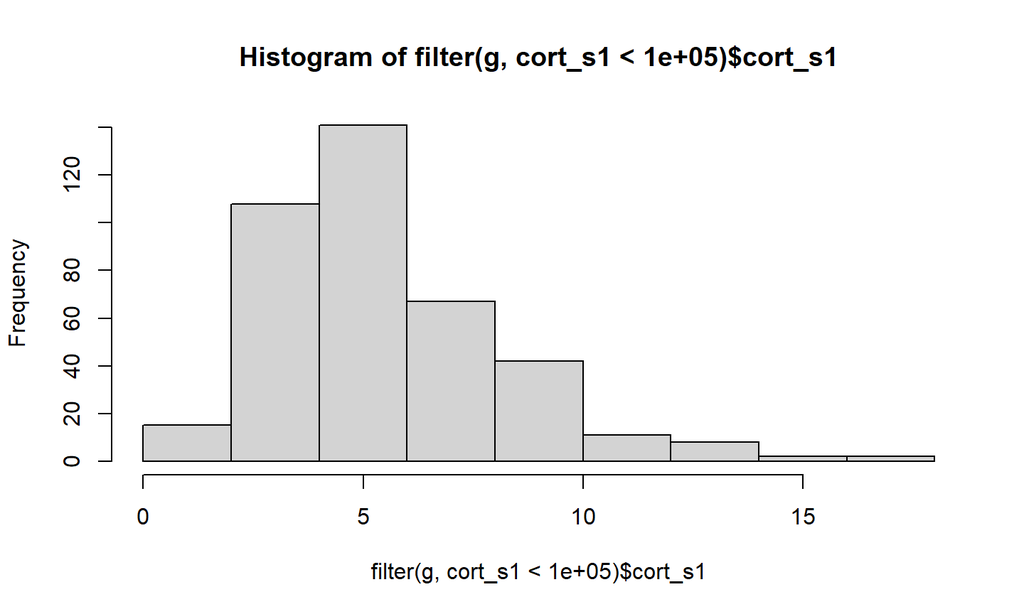

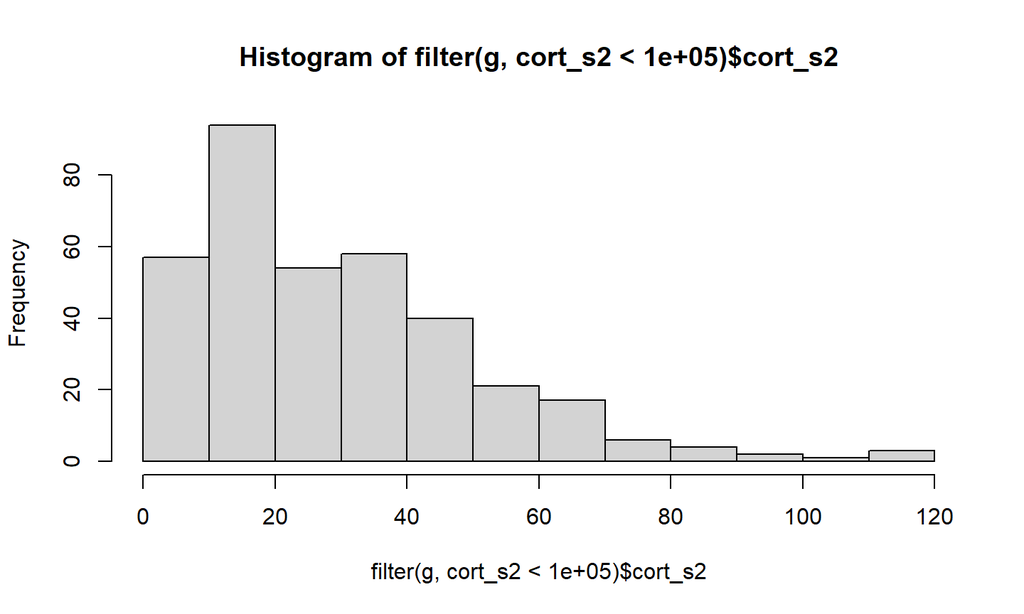

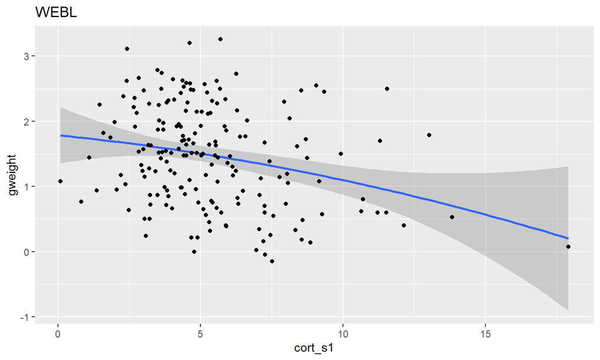

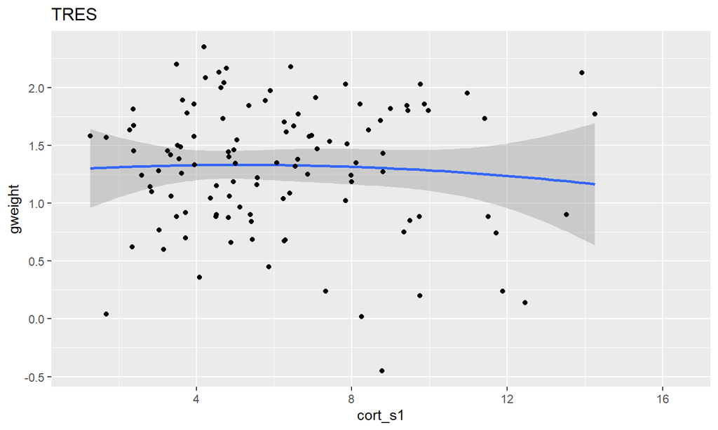

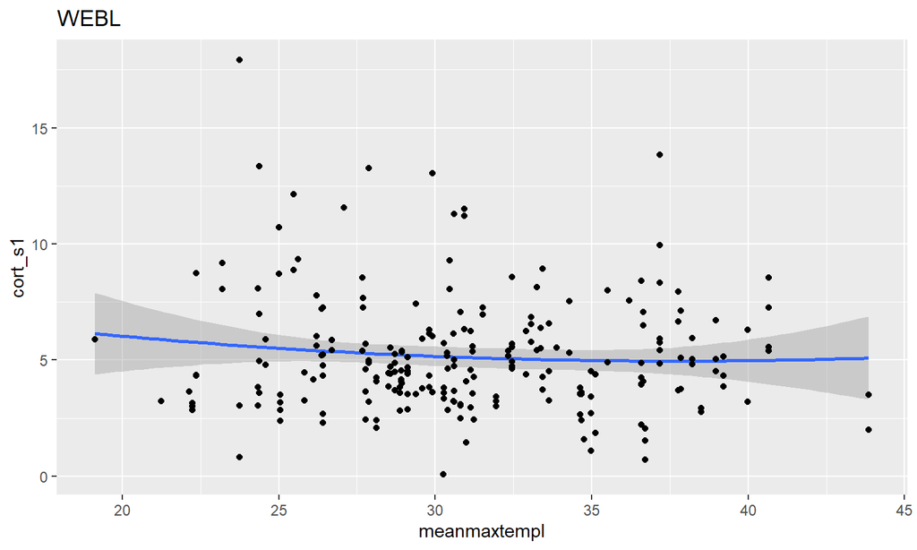

[9 more figures not shown]

## Determining main model: WEBL

- meanI_WEBL_poly: gweight_scaled ~ poly(meanmaxtempI_scaled,2,raw = TRUE) * habitat + poly(meanmintempI_scaled,2) * habitat + age + juliandate_scaled + (1|year) + (1|site/attempt_id)
- meanI_WEBL_linear: gweight_scaled ~ poly(meanmaxtempI_scaled,1,raw = TRUE) * habitat + poly(meanmaxtempI_scaled,2,raw = TRUE) + poly(meanmintempI_scaled,2) * habitat + age + juliandate_scaled + (1|year) + (1|site/attempt_id)
- meanI_WEBL_noint: gweight_scaled ~ poly(meanmaxtempI_scaled,1,raw = TRUE) + habitat + poly(meanmaxtempI_scaled,2,raw = TRUE) + poly(meanmintempI_scaled,2) * habitat + age + juliandate_scaled + (1|year) + (1|site/attempt_id)

### Is interaction significant?

| model | npar | AIC | BIC | logLik | deviance | Chisq | Df | Pr(>Chisq) |
| --- | --- | --- | --- | --- | --- | --- | --- | --- |
| no int | 20 | 985.8943 | 1067.539 | -472.9471 | 945.8943 | NA | NA | NA |
| linear int | 23 | 938.6510 | 1032.542 | -446.3255 | 892.6510 | 53.243335 | 3 | 1.626926e-11 |
| sq int | 26 | 939.0869 | 1045.225 | -443.5435 | 887.0869 | 5.564033 | 3 | 1.348585e-01 |

### Is squared term significant?

| model | npar | AIC | BIC | logLik | deviance | Chisq | Df | Pr(>Chisq) |
| --- | --- | --- | --- | --- | --- | --- | --- | --- |
| no temp | 18 | 985.5121 | 1058.992 | -474.7561 | 949.5121 | NA | NA | NA |
| linear temp | 22 | 937.2199 | 1027.029 | -446.6100 | 893.2199 | 56.292177 | 4 | 1.741363e-11 |
| sq temp | 26 | 939.0869 | 1045.225 | -443.5435 | 887.0869 | 6.133011 | 4 | 1.894327e-01 |

| model | npar | AIC | BIC | logLik | deviance | Chisq | Df | Pr(>Chisq) |
| --- | --- | --- | --- | --- | --- | --- | --- | --- |
| no sq | 22 | 937.2199 | 1027.029 | -446.6100 | 893.2199 | NA | NA | NA |
| linear int | 23 | 938.6510 | 1032.542 | -446.3255 | 892.6510 | 0.5689777 | 1 | 0.4506654 |

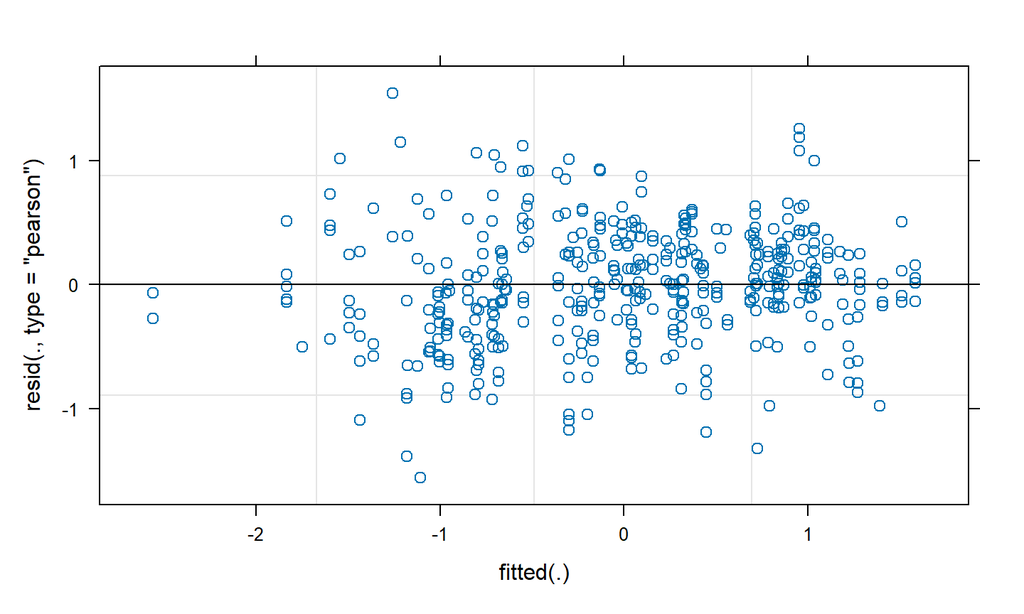

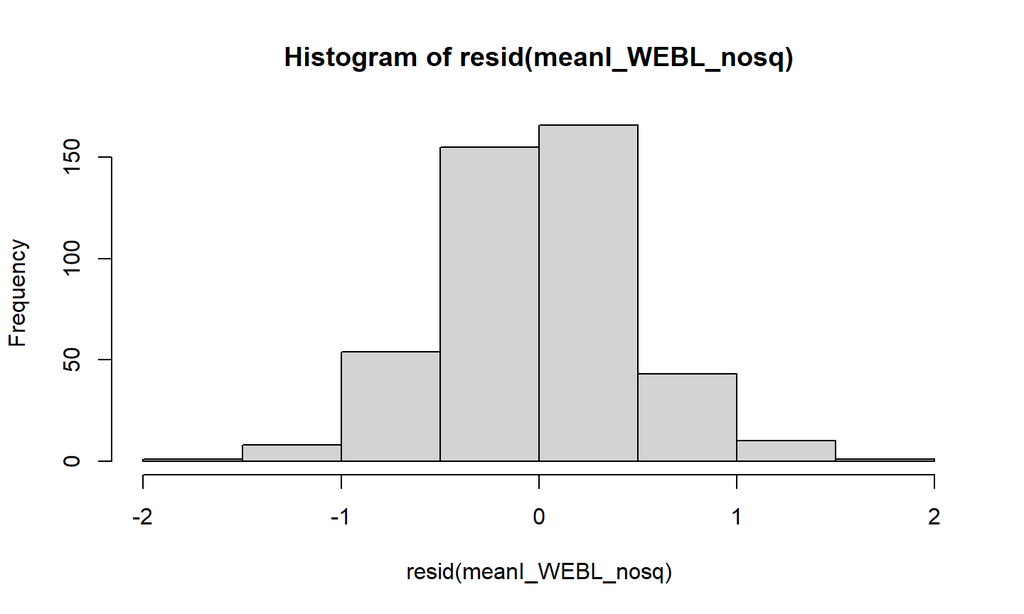

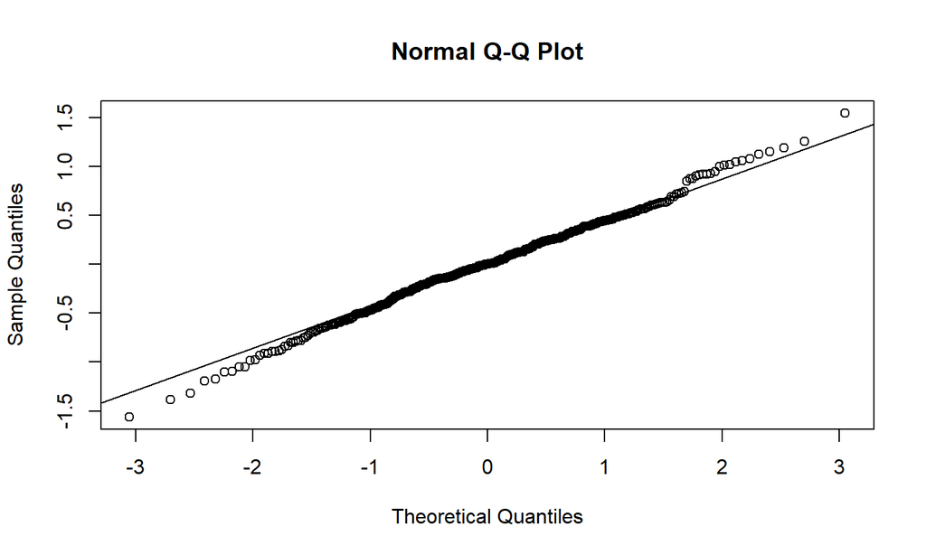

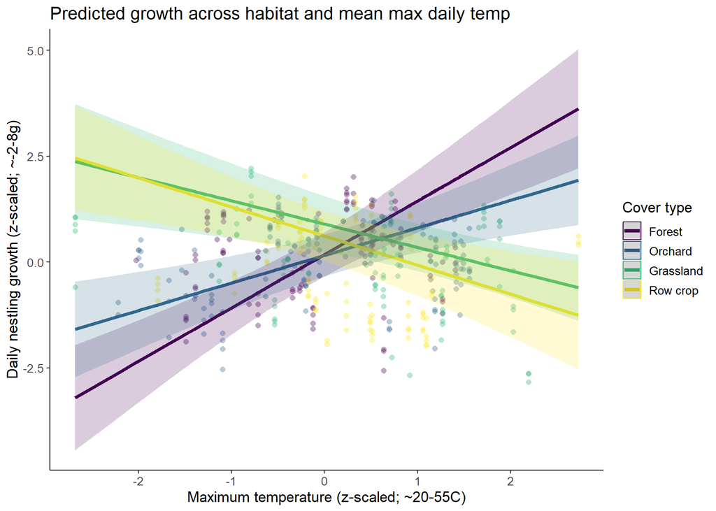

| Predictor | Estimate | SE | P-value |
| --- | --- | --- | --- |
| (Intercept) | 2.96 | 0.28 | 0.0000 |
| meanmaxtempI_scaled | 1.26 | 0.23 | 0.0000 |
| habitatOrchard | -0.11 | 0.32 | 0.7326 |
| habitatGrassland | -0.41 | 0.36 | 0.2634 |
| habitatRow crop | -0.30 | 0.33 | 0.3700 |
| poly(meanmintempI_scaled, 2)1 | -36.35 | 8.56 | 0.0000 |
| poly(meanmintempI_scaled, 2)2 | -6.72 | 6.64 | 0.3128 |
| age | -0.22 | 0.01 | 0.0000 |
| juliandate_scaled | -0.42 | 0.13 | 0.0030 |
| meanmaxtempI_scaled:habitatOrchard | -0.61 | 0.29 | 0.0379 |
| meanmaxtempI_scaled:habitatGrassland | -1.81 | 0.29 | 0.0000 |
| meanmaxtempI_scaled:habitatRow crop | -1.95 | 0.31 | 0.0000 |
| habitatOrchard:poly(meanmintempI_scaled, 2)1 | 42.55 | 11.65 | 0.0003 |
| habitatGrassland:poly(meanmintempI_scaled, 2)1 | 70.12 | 12.35 | 0.0000 |
| habitatRow crop:poly(meanmintempI_scaled, 2)1 | 58.69 | 11.40 | 0.0000 |
| habitatOrchard:poly(meanmintempI_scaled, 2)2 | 8.20 | 7.59 | 0.2816 |
| habitatGrassland:poly(meanmintempI_scaled, 2)2 | -24.94 | 9.45 | 0.0088 |
| habitatRow crop:poly(meanmintempI_scaled, 2)2 | -12.97 | 8.35 | 0.1226 |

## Determining main model: TRES

- meanI_TRES: gweight_scaled ~ poly(meanmaxtempI_scaled,2,raw = TRUE) * habitat + poly(meanmintempI_scaled,2) * habitat + age + juliandate_scaled + (1|year) + (1|site/attempt_id)
- meanI_TRES_linear: gweight_scaled ~ poly(meanmaxtempI_scaled,1,raw = TRUE) * habitat + poly(meanmaxtempI_scaled,2,raw = TRUE) + poly(meanmintempI_scaled,2) * habitat + age + juliandate_scaled + (1|year) + (1|site/attempt_id)
- meanI_TRES_noint: gweight_scaled ~ poly(meanmaxtempI_scaled,2,raw = TRUE) + habitat + poly(meanmintempI_scaled,2) * habitat + age + juliandate_scaled + (1|year) + (1|site/attempt_id)

### Is interaction significant?

| model | npar | AIC | BIC | logLik | deviance | Chisq | Df | Pr(>Chisq) |
| --- | --- | --- | --- | --- | --- | --- | --- | --- |
| no int | 20 | 839.6989 | 916.6854 | -399.8495 | 799.6989 | NA | NA | NA |
| linear int | 23 | 818.7154 | 907.2499 | -386.3577 | 772.7154 | 26.983490 | 3 | 5.934462e-06 |
| sq int | 26 | 821.8212 | 921.9037 | -384.9106 | 769.8212 | 2.894219 | 3 | 4.082238e-01 |

### Is squared temp term significant?

| model | npar | AIC | BIC | logLik | deviance | Chisq | Df | Pr(>Chisq) |
| --- | --- | --- | --- | --- | --- | --- | --- | --- |
| no temp | 18 | 839.5696 | 908.8575 | -401.7848 | 803.5696 | NA | NA | NA |
| linear temp | 22 | 819.2378 | 903.9230 | -387.6189 | 775.2378 | 28.331779 | 4 | 1.068317e-05 |
| sq temp | 26 | 821.8212 | 921.9037 | -384.9106 | 769.8212 | 5.416622 | 4 | 2.471562e-01 |

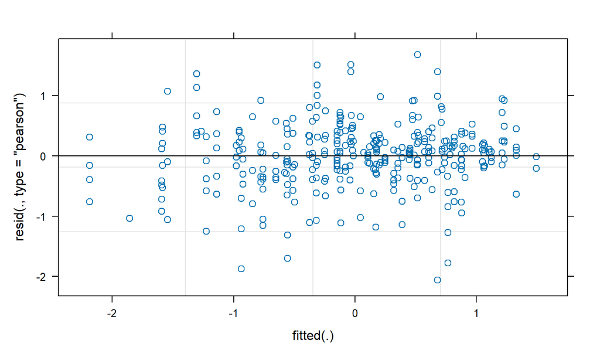

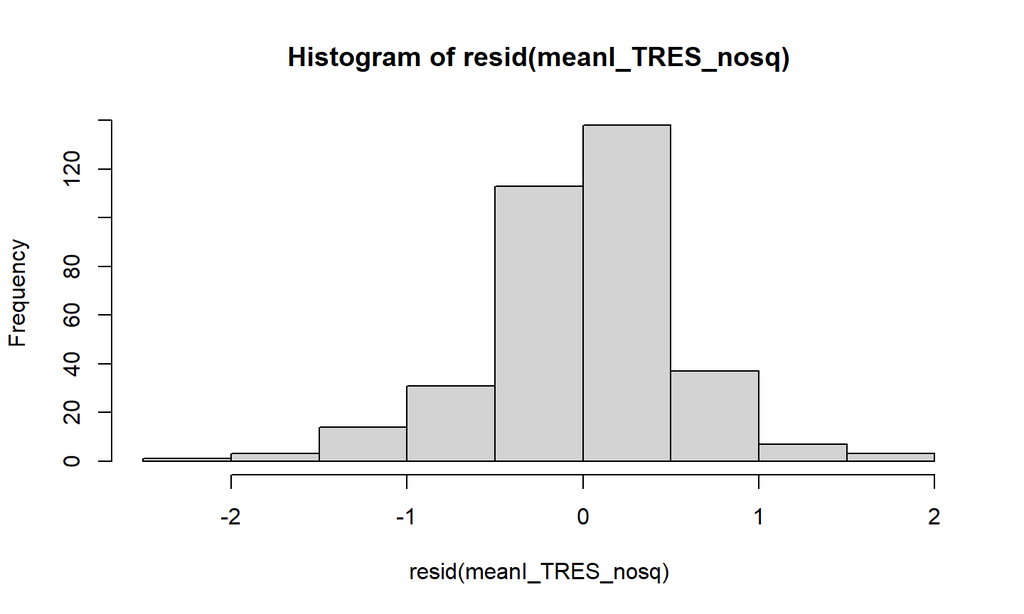

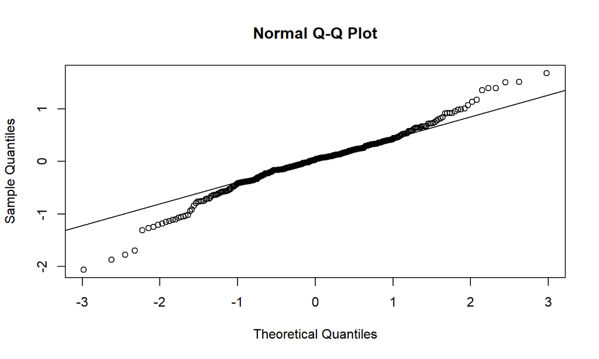

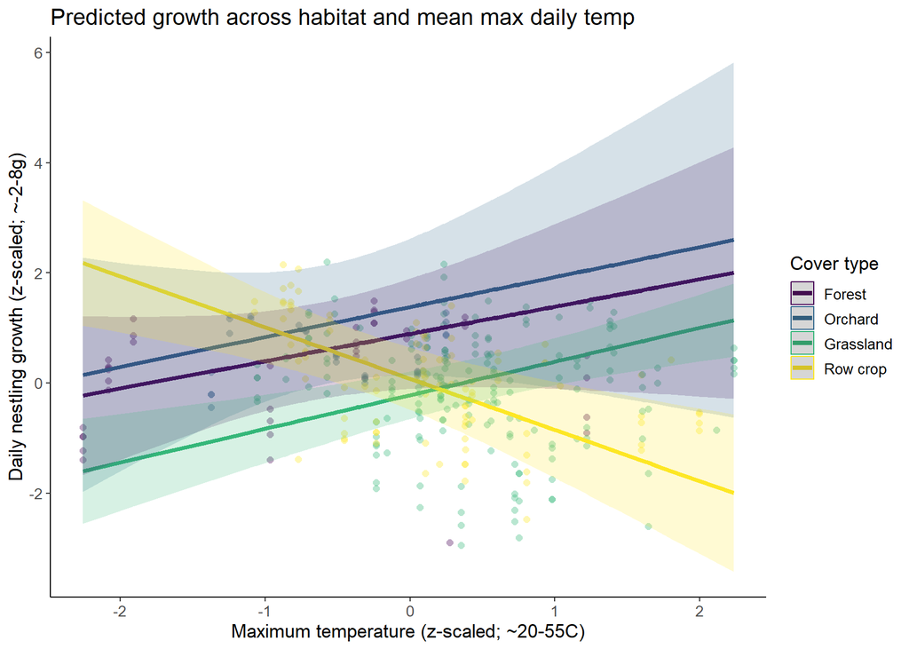

| Predictor | Estimate | SE | P-value |
| --- | --- | --- | --- |
| (Intercept) | 1.49 | 0.50 | 0.0036 |
| meanmaxtempI_scaled | 0.49 | 0.37 | 0.1813 |
| habitatOrchard | 0.75 | 0.71 | 0.3000 |
| habitatGrassland | -0.52 | 0.53 | 0.3283 |
| habitatRow crop | 0.83 | 0.62 | 0.1830 |
| poly(meanmintempI_scaled, 2)1 | 15.77 | 13.58 | 0.2482 |
| poly(meanmintempI_scaled, 2)2 | -29.37 | 9.56 | 0.0026 |
| age | -0.11 | 0.02 | 0.0000 |
| juliandate_scaled | -0.18 | 0.14 | 0.2172 |
| meanmaxtempI_scaled:habitatOrchard | 0.05 | 0.65 | 0.9397 |
| meanmaxtempI_scaled:habitatGrassland | 0.11 | 0.38 | 0.7644 |
| meanmaxtempI_scaled:habitatRow crop | -1.42 | 0.44 | 0.0015 |
| habitatOrchard:poly(meanmintempI_scaled, 2)1 | 3.26 | 29.48 | 0.9123 |
| habitatGrassland:poly(meanmintempI_scaled, 2)1 | -26.11 | 14.14 | 0.0675 |
| habitatRow crop:poly(meanmintempI_scaled, 2)1 | -54.20 | 22.80 | 0.0186 |
| habitatOrchard:poly(meanmintempI_scaled, 2)2 | 13.34 | 22.88 | 0.5621 |
| habitatGrassland:poly(meanmintempI_scaled, 2)2 | 20.39 | 10.13 | 0.0463 |
| habitatRow crop:poly(meanmintempI_scaled, 2)2 | 62.36 | 13.65 | 0.0000 |

## Triple interaction with humidity: WEBL

- Main model (meanI_WEBL_nosq): gweight_scaled ~ meanmaxtempI_scaled * habitat + poly(meanmintempI_scaled,2) * habitat + age + juliandate_scaled + (1|year) + (1|site/attempt_id)
- Additive model (meanI_WEBL_humadd): gweight_scaled ~ meanmaxtempI_scaled * habitat + habitat * meanh_scaled + meanmaxtempI_scaled * meanh_scaled + poly(meanmintempI_scaled,2) * habitat + age + juliandate_scaled + (1|year) + (1|site/attempt_id)
- Interaction with temp only (meanI_WEBL_humbytemp): gweight_scaled ~ meanmaxtempI_scaled * habitat + meanmaxtempI_scaled * meanh_scaled + poly(meanmintempI_scaled,2) * habitat + age + juliandate_scaled + (1|year) + (1|site/attempt_id)
- No habitat (meanI_WEBL_humnohab): gweight_scaled ~ meanmaxtempI_scaled * meanh_scaled + poly(meanmintempI_scaled,2) * habitat + age + juliandate_scaled + (1|year) + (1|site/attempt_id)

### Is interaction significant?

| model | npar | AIC | BIC | logLik | deviance | Chisq | Df | Pr(>Chisq) |
| --- | --- | --- | --- | --- | --- | --- | --- | --- |
| no habitat | 21 | 566.0309 | 641.5198 | -262.0154 | 524.0309 | NA | NA | NA |
| main model: no humidity | 22 | 554.5742 | 633.6579 | -255.2871 | 510.5742 | 13.456663 | 1 | 2.441376e-04 |
| humidity * temp | 24 | 500.3925 | 586.6655 | -226.1962 | 452.3925 | 58.181759 | 2 | 2.322692e-13 |
| double interactions | 27 | 500.8105 | 597.8677 | -223.4052 | 446.8105 | 5.581961 | 3 | 1.338178e-01 |
| triple interaction | 30 | 484.8571 | 592.6984 | -212.4285 | 424.8571 | 21.953402 | 3 | 6.670372e-05 |

| model | npar | AIC | BIC | logLik | deviance | Chisq | Df | Pr(>Chisq) |
| --- | --- | --- | --- | --- | --- | --- | --- | --- |
| main model: no humidity | 22 | 554.5742 | 633.6579 | -255.2871 | 510.5742 | NA | NA | NA |
| triple interaction | 30 | 484.8571 | 592.6984 | -212.4285 | 424.8571 | 85.71712 | 8 | 3.43133e-15 |

| model | npar | AIC | BIC | logLik | deviance | Chisq | Df | Pr(>Chisq) |
| --- | --- | --- | --- | --- | --- | --- | --- | --- |
| humidity * temp | 24 | 500.3925 | 586.6655 | -226.1962 | 452.3925 | NA | NA | NA |
| triple interaction | 30 | 484.8571 | 592.6984 | -212.4285 | 424.8571 | 27.53536 | 6 | 0.0001149088 |

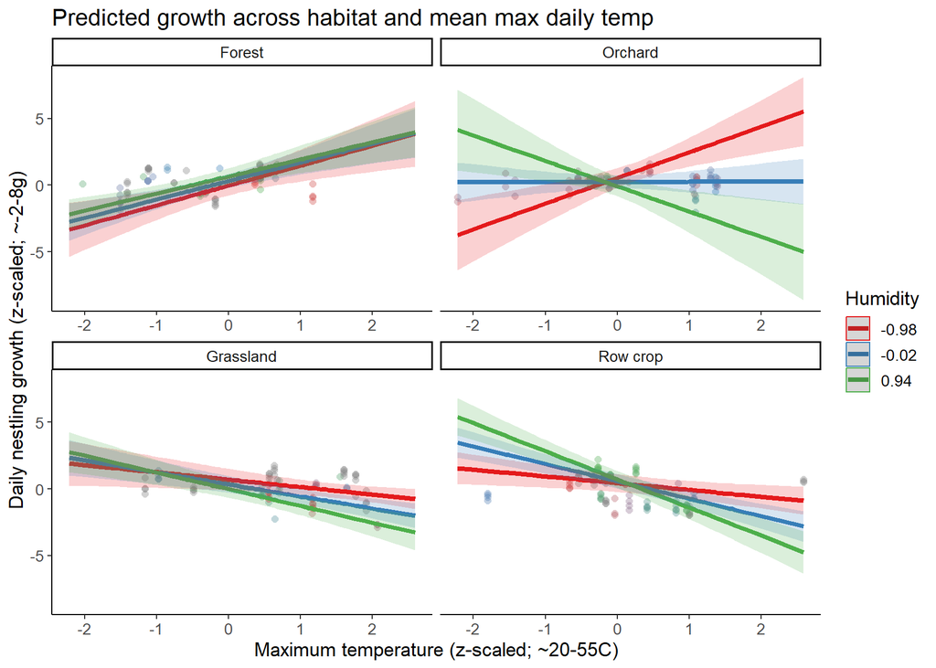

## Triple interaction with humidity: TRES

### Is interaction significant?

| model | npar | AIC | BIC | logLik | deviance | Chisq | Df | Pr(>Chisq) |
| --- | --- | --- | --- | --- | --- | --- | --- | --- |
| no habitat | 21 | 736.3097 | 815.1138 | -347.1549 | 694.3097 | NA | NA | NA |
| main model: no humidity | 22 | 727.8814 | 810.4380 | -341.9407 | 683.8814 | 10.42834 | 1 | 1.240959e-03 |
| humidity * temp | 24 | 717.9200 | 807.9817 | -334.9600 | 669.9200 | 13.96141 | 2 | 9.296478e-04 |
| additive model | 27 | 720.5537 | 821.8732 | -333.2769 | 666.5537 | 3.36626 | 3 | 3.385264e-01 |
| triple interaction | 30 | 685.1097 | 797.6869 | -312.5548 | 625.1097 | 41.44404 | 3 | 5.264250e-09 |

| model | npar | AIC | BIC | logLik | deviance | Chisq | Df | Pr(>Chisq) |
| --- | --- | --- | --- | --- | --- | --- | --- | --- |
| main model: no humidity | 22 | 727.8814 | 810.4380 | -341.9407 | 683.8814 | NA | NA | NA |
| additive model | 27 | 720.5537 | 821.8732 | -333.2769 | 666.5537 | 17.32767 | 5 | 0.003918513 |

| model | npar | AIC | BIC | logLik | deviance | Chisq | Df | Pr(>Chisq) |
| --- | --- | --- | --- | --- | --- | --- | --- | --- |
| humidity * temp | 24 | 717.9200 | 807.9817 | -334.9600 | 669.9200 | NA | NA | NA |
| additive model | 27 | 720.5537 | 821.8732 | -333.2769 | 666.5537 | 3.36626 | 3 | 0.3385264 |

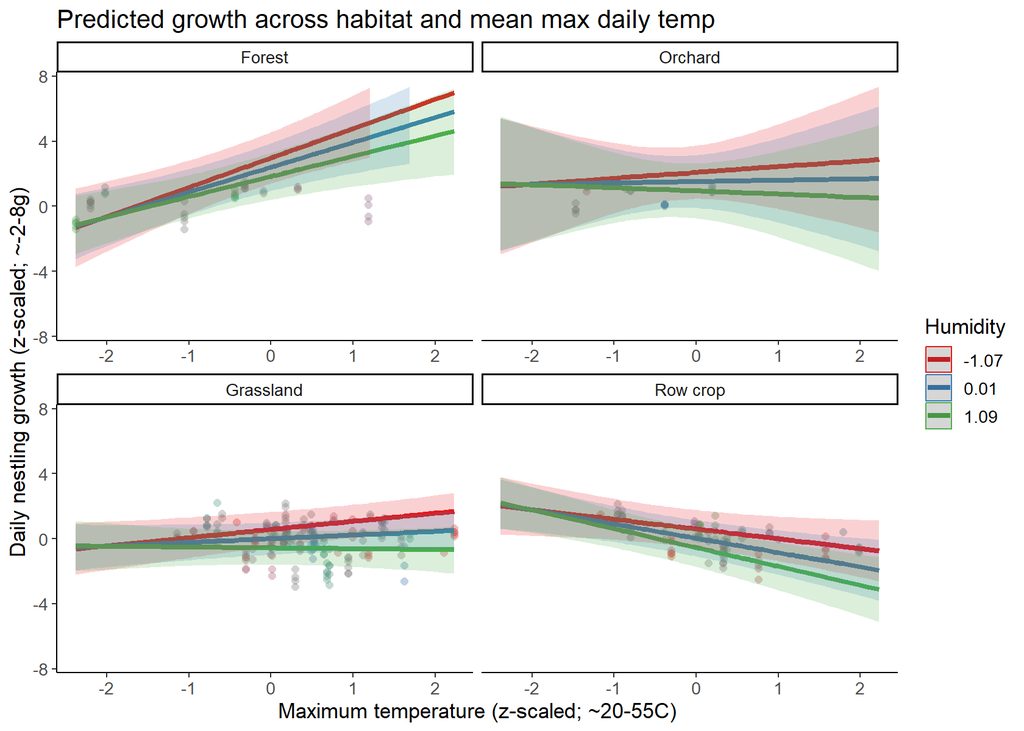

## Beginning cort explorations

Data prep:

```r
c <- read_rds("../data/cort_with_id.rds")
```

### Variation in baseline cort within nest and occasion : WEBL

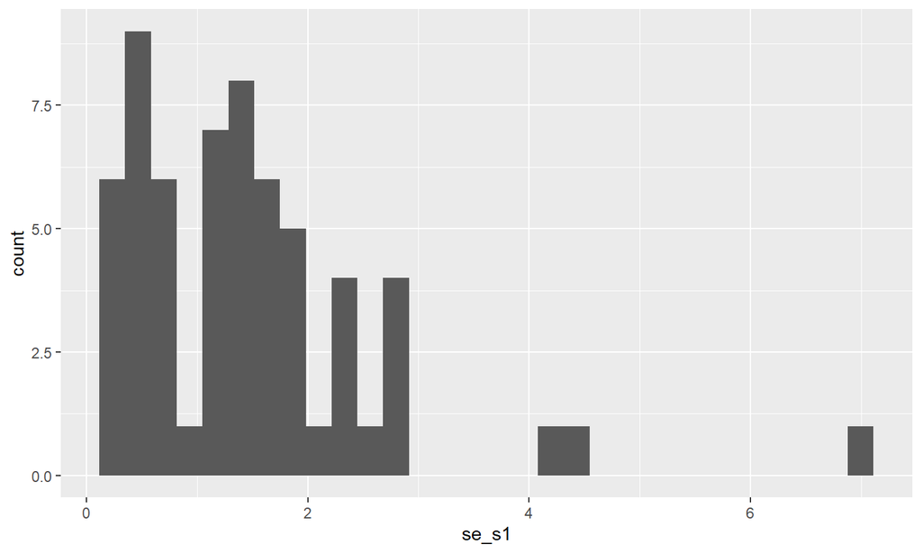

### Variation in stressed cort within attempt and occasion WEBL

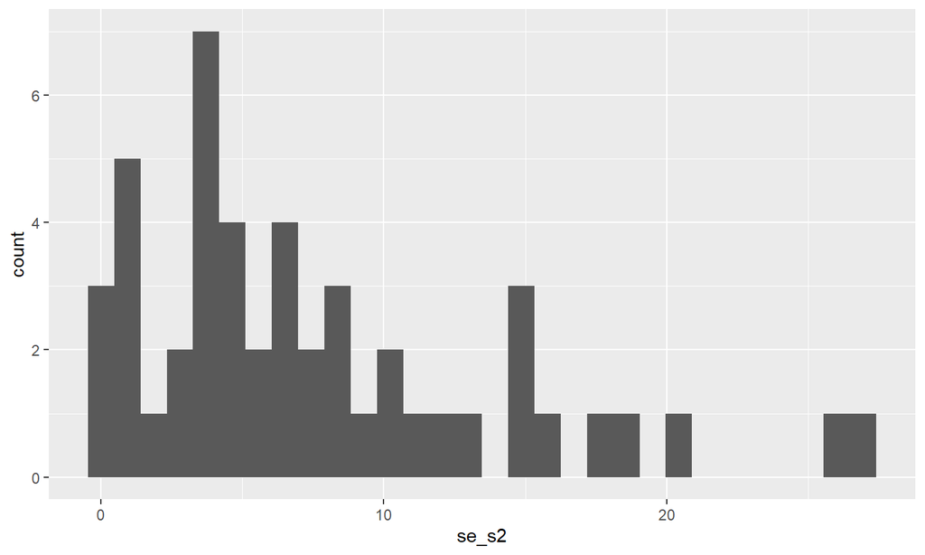

### Variation in condition within attempt and occasion WEBL

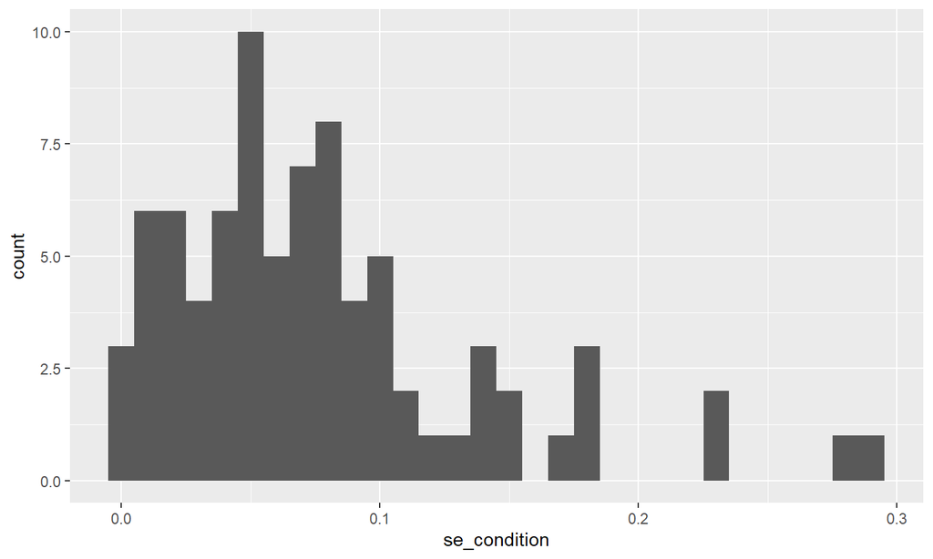

### Variation in baseline cort within nest and occasion : TRES

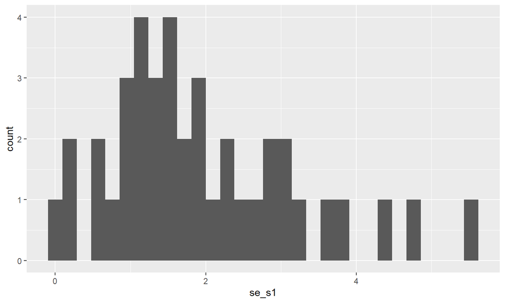

### Variation in stressed cort within attempt and occasion TRES

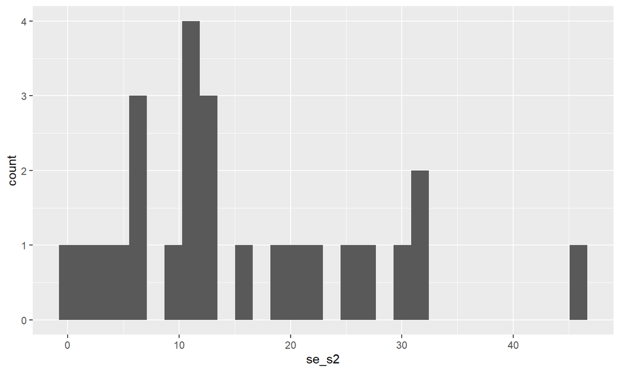

### Variation in condition within attempt and occasion TRES

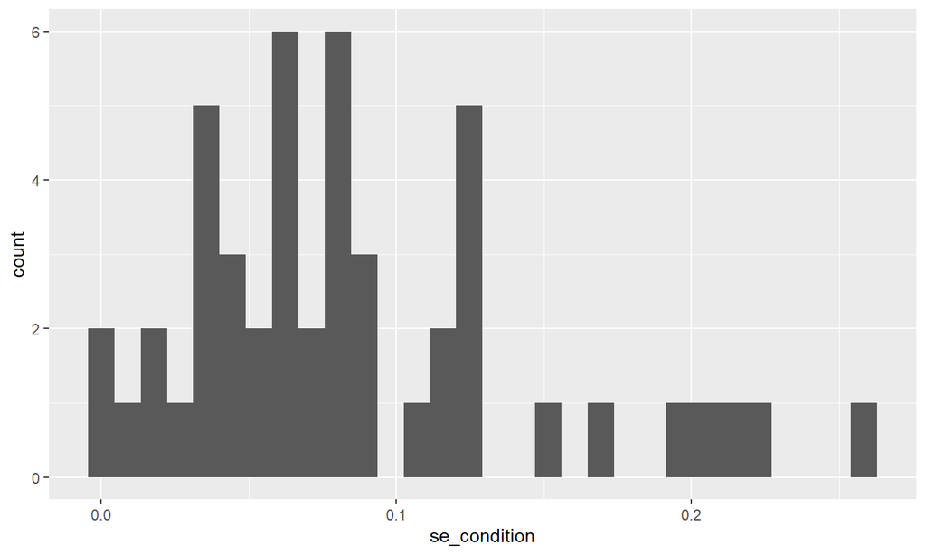

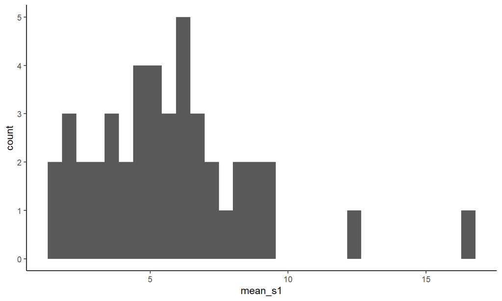

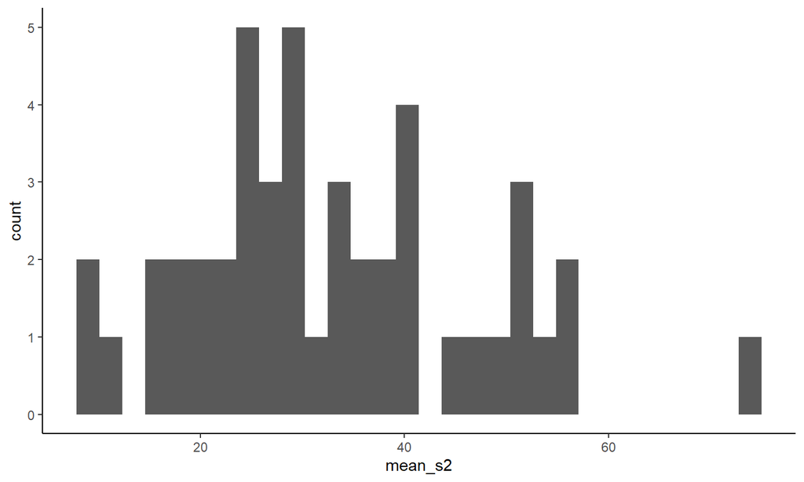

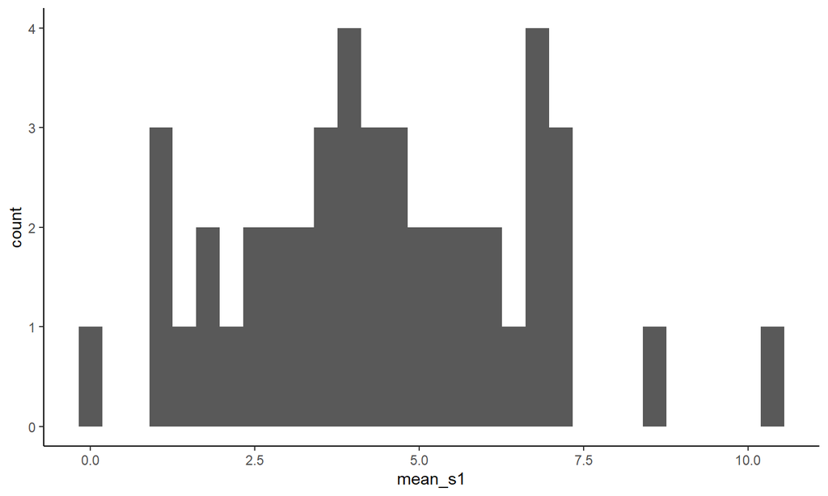

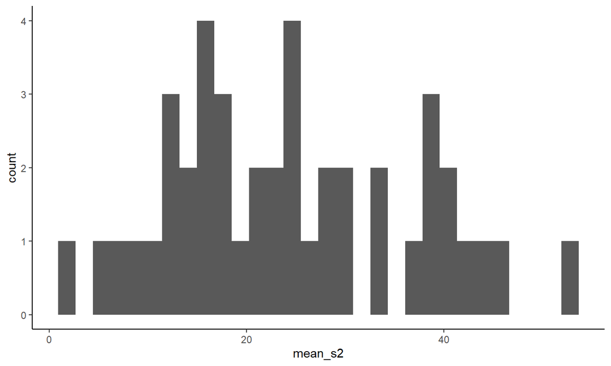